# TP2

Kalidou BA (kalidou.ba@u-bordeaux.fr)

11 Septembre 2024

# Jeu de données gapminder

Ce jeu de données se compose de $1704$ observations et de $6$ variables. Ces variables sont :

- `country` (Qualitative) : Le pays
- `continent` (Qualitative) : Le continent
- `year` : L’année
- `LifeExp` (Numérique) : l’espérance de vie
- `pop` (Numérique) : Le nombre d’habitants
- `gdpPercap`(Numérique) : Le PIB par habitant

# Manipulation de données et statistiques descriptives

1. Dans un objet `gapminder` importer le jeu de données. Recoder le type des variables si nécessaire.

```r
gapminder <- read.csv(file = "gapminder.csv", header = T)

gapminder$country <- as.factor(gapminder$country)
gapminder$continent <- as.factor(gapminder$continent)
```

Les variables country et continent peuvent être recodées en type factor

```r
gapminder$country <- as.factor(gapminder$country)
gapminder$continent <- as.factor(gapminder$continent)
```

2. Pour combien de pays différents les données sont-elles disponibles ?

```r
length(levels(gapminder$country))
```

```
## [1] 142
```

La fonction length renvoie la taille d’un vecteur

3. Afficher la liste des différentes années pour lesquelles des données sont disponibles (fonction `unique()`)

```r
unique(gapminder$year)
```

```
##  [1] 1952 1957 1962 1967 1972 1977 1982 1987 1992 1997 2002 2007
```

# Fonction

4. Créer une fonction `moyenne()` qui prend comme argument une variable numérique et renvoie sa moyenne empirique. Appliquer-là sur les variables numériques disponibles dans les données et comparer les résultats avec ceux renvoyés par la fonction `mean()` de R.
- Etape 1 : Création de la fonction avec `function(){}` prenant comme argument un vecteur `x`
- Etape 2 : Récupérer dans un objet `n` le nombre d’observations contenues dans le vecteur `x` (fonction `length()`)
- Etape 3 : Calcul de la moyenne dans un objet `moy`
- Etape 4 : Renvoyer l’objet `moy` à l’aide de la fonction `return()`

```r
moyenne <- function(x){
  n <- length(x)
  moy <- 1/n*(sum(x))
  return(moy)
}
moyenne(gapminder$pop)
```

```
## [1] 29601212
```

```r
mean(gapminder$pop)
```

```
## [1] 29601212
```

5. Créer une fonction `ecart_type()` qui prend comme argument une variable numérique et renvoie son écart type empirique. Appliquer-là sur les variables numériques disponibles dans les données et comparer les résultats avec ceux renvoyés par la fonction `sd()` de R. Qu’observez-vous ?

```r
ecart_type <- function(x){
  n <- length(x)
  moy <- moyenne(x)
  variance <- (1/n)*(sum((x-moy)^2))
  return(sqrt(variance))
}
ecart_type(gapminder$pop)
```

```
## [1] 106126743
```

```r
sd_pop <- sd(gapminder$pop)
sd_pop
```

```
## [1] 106157897
```

On observe que les deux fonctions ne renvoient pas la même valeur : la fonction sd() de R renvoie la valeur de l’écart type empirique corrigé (1/n-1).

```r
n <- nrow(gapminder)
sqrt(((n-1)/n)*sd_pop^2)
```

```
## [1] 106126743
```

6. Créer une fonction `gapminder_year()` permettant de récupérer le sous-ensemble de données correspondant à une année particulière spécifiée par l’utilisateur en argument.

```r
gapminder_year <- function(year){
  gm_year <- gapminder[which(gapminder$year == year),]
  return(gm_year)
}
```

7. A l’aide de cette fonction, créer un objet `gapminder_2007` contenant le sous-ensemble de données concernant l’année 2007. Supprimer ensuite la colonne `year` de ce nouveau jeu de données.

```r
gapminder2007 <- gapminder_year(2007)
gapminder2007$year <- NULL
```

8. Modifier la fonction `gapminder_year()` afin de tester si le sous-ensemble de données contient bien au moins une ligne (en utilisant `if` et `else`) et qui renvoie un message d’erreur si ce n’est pas le cas (grâce à la fonction `warning()`). *Il s’agit d’un moyen de vérifier qu’il y a bien des données disponibles pour l’année sélectionnée par l’utilisateur dans nos données*. Tester la fonction avec les années 2007 et 2021.

```r
gapminder_year <- function(year){
  gm_year <- gapminder[which(gapminder$year == year),]
  if (nrow(gm_year)>0){
      return(gm_year)
  }
  else {
    warning(paste("Aucune donée disponible pour l'année", year), "\n")
  }
}
gapminder_year(2007)
```

```
##                       country continent year lifeExp        pop  gdpPercap
## 12                Afghanistan      Asia 2007  43.828   31889923   974.5803
## 24                    Albania    Europe 2007  76.423    3600523  5937.0295
## 36                    Algeria    Africa 2007  72.301   33333216  6223.3675
## 48                     Angola    Africa 2007  42.731   12420476  4797.2313
## 60                  Argentina  Americas 2007  75.320   40301927 12779.3796
## 72                  Australia   Oceania 2007  81.235   20434176 34435.3674
## 84                    Austria    Europe 2007  79.829    8199783 36126.4927
## 96                    Bahrain      Asia 2007  75.635     708573 29796.0483
## 108                Bangladesh      Asia 2007  64.062  150448339  1391.2538
## 120                   Belgium    Europe 2007  79.441   10392226 33692.6051
## 132                     Benin    Africa 2007  56.728    8078314  1441.2849
## 144                   Bolivia  Americas 2007  65.554    9119152  3822.1371
## 156    Bosnia and Herzegovina    Europe 2007  74.852    4552198  7446.2988
## 168                  Botswana    Africa 2007  50.728    1639131 12569.8518
```

[output cut: 128 more lines]

9. A l’aide des fonctions précédentes, créer une fonction prenant comme arguments une année et un continent qui renvoie l’espérance de vie moyenne sur le continent pour l’année sélectionnée. Tester la fonction pour calculer l’espérance de vie moyenne en Europe en 1952.

```r
mean_LifeExp_year_cont <- function(year, continent){
  gm_year <- gapminder_year(year = year)
  gm_year_cont <- gm_year[which(gm_year$continent == continent),]
  return(moyenne(gm_year_cont$lifeExp))
}

esp <- function(df, annee, continent){
  set <- subset(df, year == annee & continent == continent)
  return(mean(set$lifeExp))
}

mean_LifeExp_year_cont(year = 1952, continent = "Europe")
```

```
## [1] 64.4085
```

10. On voudrait maintenant obtenir l’évolution de l’espérance de vie moyenne en Europe au cours du temps.
- Etape 1 : Récupérer l’ensemble des années disponibles de l’étude dans un objet `year` (à l’aide de la fonction `unique()`)
- Etape 2 : Créer un vecteur `mean_LifeExp_Europe` contenant autant de `NA` qu’il y a d’années (ce vecteur servira à sauvegarder les valeurs de l’espérance de vie moyenne en Europe pour chaque année)
- Etape 3 : A l’aide d’une boucle `for` et de la fonction précédente, calculer, pour chaque année possible, la valeur moyenne de l’espérance de vie en Europe et l’enregistrer dans le vecteur `mean_LifeExp_Europe`
- Etape 4 : Représenter graphiquement l’évolution de l’espérance de vie moyenne en Europe au cours du temps

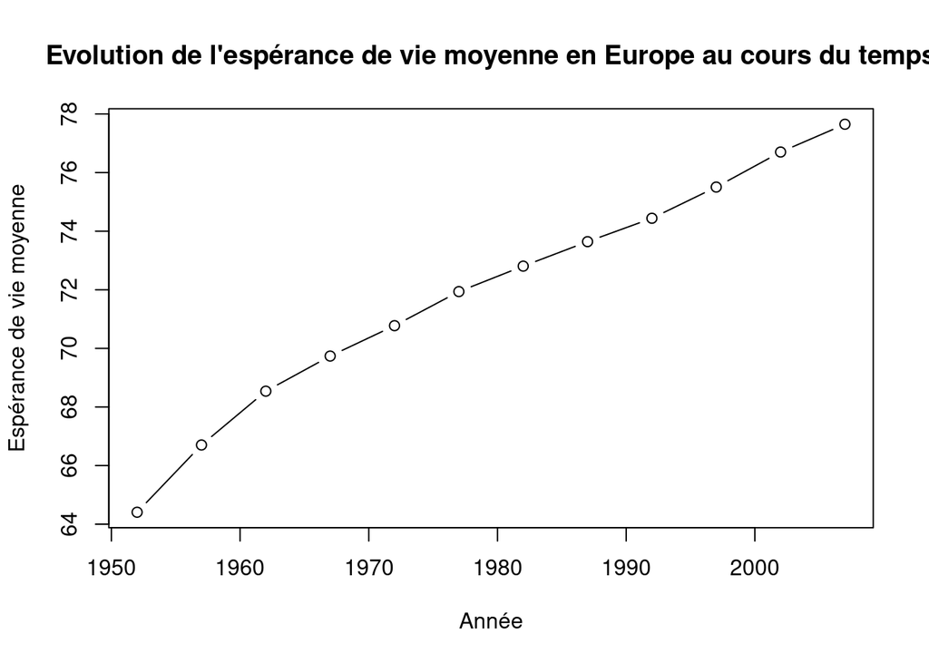

```r
year <- unique(gapminder$year)
mean_LifeExp_Europe <- rep(NA, length(year))

for (i in 1:length(year)){
  mean_LifeExp_Europe[i] <- mean_LifeExp_year_cont(year = year[i], continent = "Europe")
}

plot(year, mean_LifeExp_Europe, type = "b",
     main = "Evolution de l'espérance de vie moyenne en Europe au cours du temps",
     xlab = "Année",
     ylab = "Espérance de vie moyenne")
```

# Graphiques avec ggplot2

**Aide :** https://thinkr.fr/pdf/ggplot2-french-cheatsheet.pdf

11. Installer et charger le package `ggplot2`

```r
# install.package(ggplot2)
library(ggplot2)
```

12. Représenter le nuage de points de l’espérance de vie (variable `lifeExp`) en fonction de du PIB par habitant (variable `gdpPercap`) à l’aide de ggplot

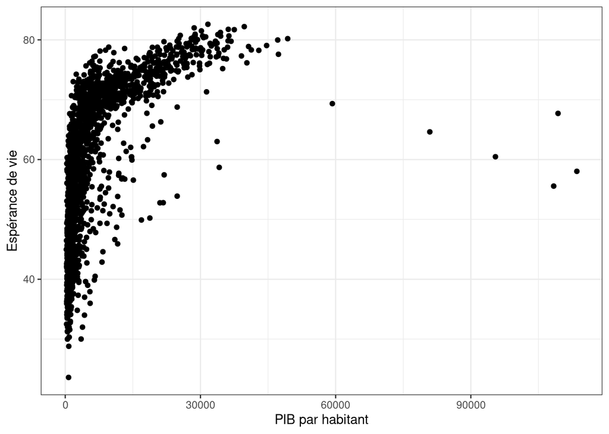

```r
ggplot(gapminder) + aes(x=gdpPercap, y=lifeExp) + geom_point() +
  xlab("PIB par habitant") +
  ylab("Espérance de vie") +
  theme_bw()
```

13. Refaire le même nuage de points en ajoutant une coloration des points en fonction du continent dans lequel il se trouve

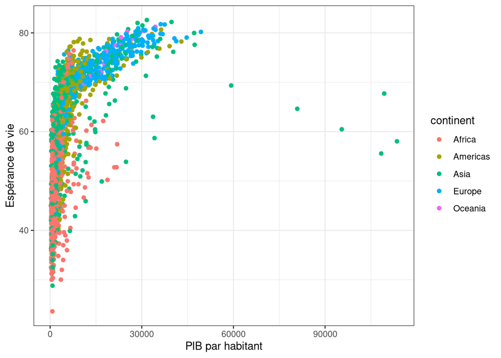

```r
ggplot(gapminder) + aes(x=gdpPercap, y=lifeExp, colour = continent) + geom_point() +
  xlab("PIB par habitant") +
  ylab("Espérance de vie") +
  theme_bw()
```

14. Modifier le nom des modalités (les écrire en français) et les couleurs par défaut des points avec les arguments `labels` et `values` de la fonction `scale_color_manual()`

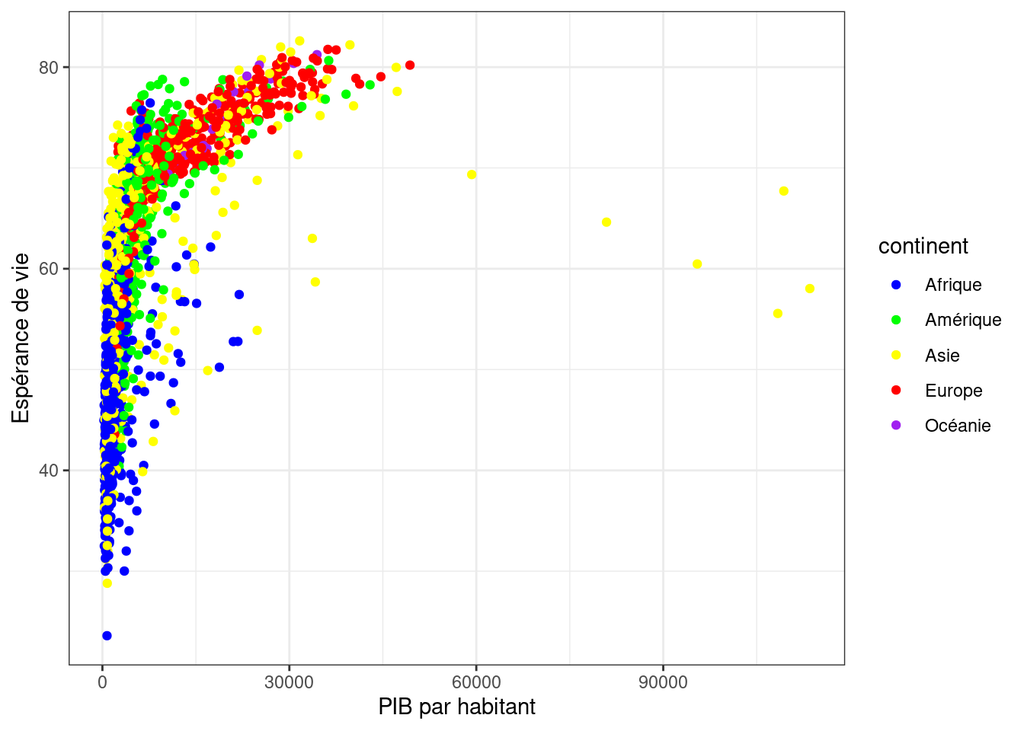

```r
ggplot(gapminder) + aes(x=gdpPercap, y=lifeExp, colour = continent) + geom_point() +
  xlab("PIB par habitant") +
  ylab("Espérance de vie") +
  scale_colour_manual(labels = c("Afrique", "Amérique", "Asie", "Europe", "Océanie"),
                      values = c("blue", "green", "yellow", "red", "purple")) +
  theme_bw()
```

15. Tracer les boxplots de la population dans les différents pays de l’Océanie (`geom_boxplot()`) *On commencera par créer un jeu de données ne contenant que les observations de pays en Océanie*

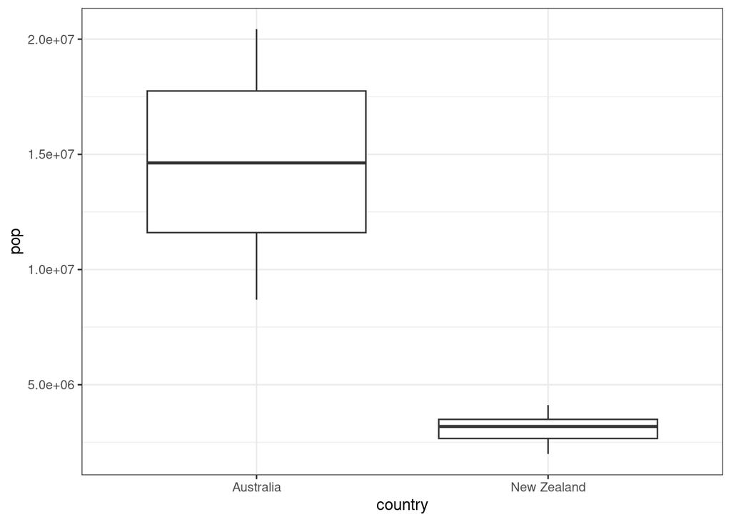

```r
gapminderOceanie <- subset(gapminder, continent == "Oceania")
ggplot(gapminderOceanie) + aes(x=country, y = pop) + geom_boxplot() +
  theme_bw()
```

16. Changer la couleur et le remplissage des boxplots ci-dessus (arguments `color` et `fill` de la fonction `geom_boxplot()`)

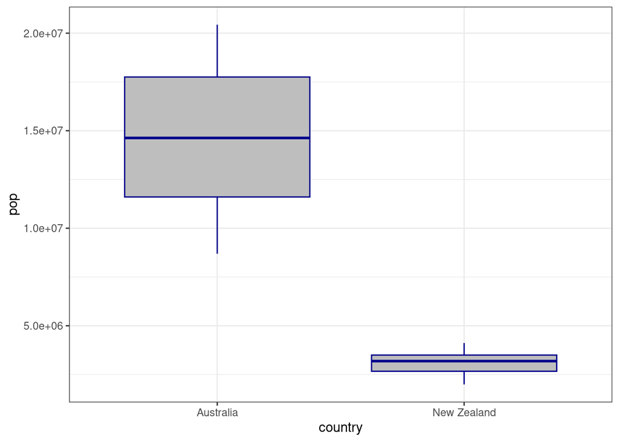

```r
gapminderOceanie <- subset(gapminder, continent == "Oceania")
ggplot(gapminderOceanie) + aes(x=country, y = pop) + geom_boxplot(color = "darkblue", fill = "grey") +
  theme_bw()
```

16. Tracer la densité de la variable `gdpPercap` (`geom_density()`) pour l’année 2007

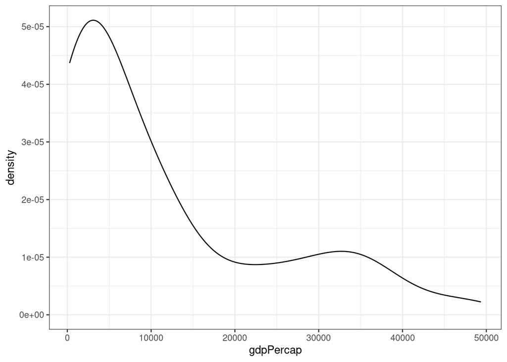

```r
ggplot(gapminder2007) + aes(x=gdpPercap) + geom_density() +
  theme_bw()
```

17. Tracer la densité du PIB par habitant pour l’année 2007 en rajoutant un remplissage en fonction du continent et changer l’opacité de ce dernier (argument `alpha`)

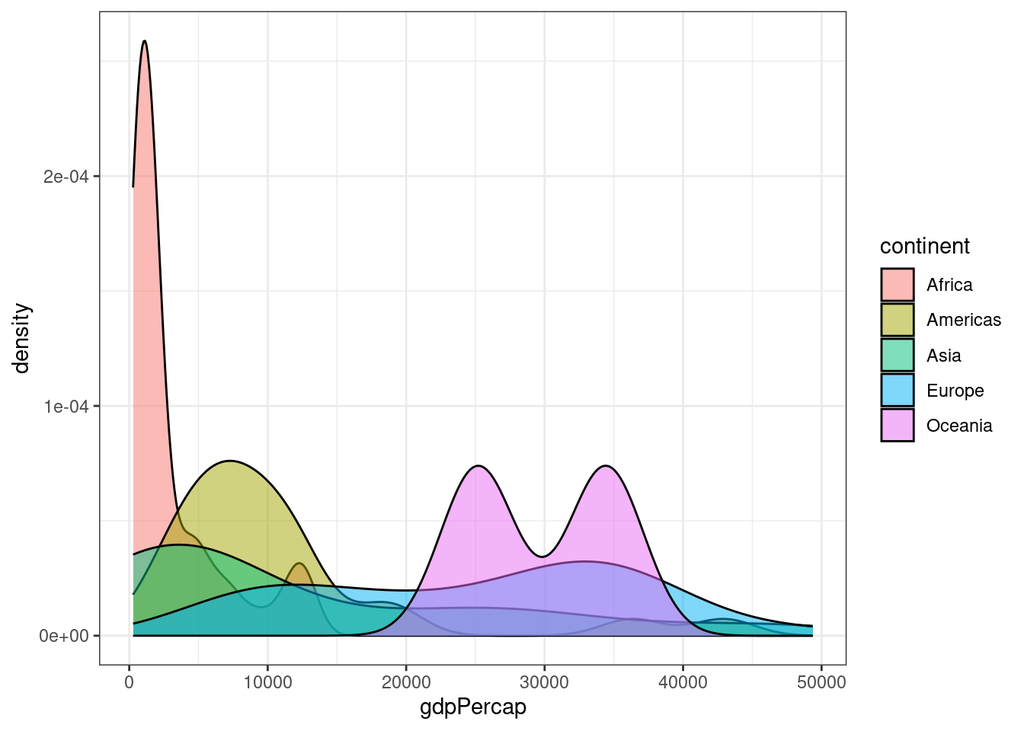

```r
ggplot(gapminder2007) + aes(x=gdpPercap, fill = continent) + geom_density(alpha = .5) +
  theme_bw()
```

18. Tracer l’évolution de l’espérance de vie moyenne en Europe au cours du temps avec les fonctions de ggplot.

*ggplot n’utilise que des objets de classe `data.frame`, il faut donc créer un jeu de données à l’aide de la fonction `data.frame()` contenant deux colonnes : une pour les années et l’autre pour l’espérance de vie moyenne calculée à la question 10*

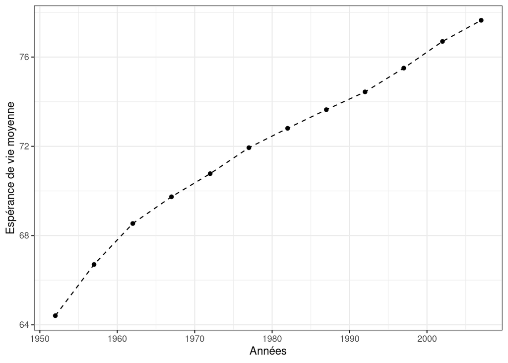

```r
meanLifeExpEurope <- data.frame(Year = year, MeanLifeExp = mean_LifeExp_Europe)

ggplot(meanLifeExpEurope) + aes(x=Year, y = MeanLifeExp) +
  geom_point() +
  geom_line(linetype = "dashed") +
  xlab("Années") +
  ylab("Espérance de vie moyenne") +
  theme_bw()
```

# Bonus : le tidyverse

**Aide :** https://s3.amazonaws.com/assets.datacamp.com/blog_assets/Tidyverse+Cheat+Sheet.pdf

```r
library(tidyverse)
```

20. A l’aide des fonctions des packages du `tidyvserse` :
- Créer un jeu de données contenant uniquement les observations pour les années 1952 et 1957 pour les continents Afrique et Asie

```r
gapminder1952_1957 <- filter(gapminder, year %in% c(1952, 1957) & continent %in% c("Asia", "Africa"))
```

- Arranger les valeurs du jeux de donnée par ordre croissant d’années et décroissant de population

```r
arrange(gapminder1952_1957, year, desc(pop))
```

```
##                      country continent year  lifeExp       pop   gdpPercap
## 1                      China      Asia 1952 44.00000 556263527    400.4486
## 2                      India      Asia 1952 37.37300 372000000    546.5657
## 3                      Japan      Asia 1952 63.03000  86459025   3216.9563
## 4                  Indonesia      Asia 1952 37.46800  82052000    749.6817
## 5                 Bangladesh      Asia 1952 37.48400  46886859    684.2442
## 6                   Pakistan      Asia 1952 43.43600  41346560    684.5971
## 7                    Nigeria    Africa 1952 36.32400  33119096   1077.2819
## 8                    Vietnam      Asia 1952 40.41200  26246839    605.0665
## 9                Philippines      Asia 1952 47.75200  22438691   1272.8810
## 10                     Egypt    Africa 1952 41.89300  22223309   1418.8224
## 11                  Thailand      Asia 1952 50.84800  21289402    757.7974
## 12               Korea, Rep.      Asia 1952 47.45300  20947571   1030.5922
## 13                  Ethiopia    Africa 1952 34.07800  20860941    362.1463
## 14                   Myanmar      Asia 1952 36.31900  20092996    331.0000
```

[output cut: 156 more lines]

- Recoder la variable continent pour que ces modalités soient “Asie” et “Afrique”

```r
gapminder1952_1957$continent <- fct_recode(gapminder1952_1957$continent,
                                           "Asie" = "Asia",
                                           "Afrique" = "Africa")
```

- Créer un nouveau jeu de données contenant une variable moyenne et une variable écart type donnant respectivement le PIB moyens et son écart type

```r
summarise(gapminder1952_1957, mean = mean(gdpPercap), sd = sd(gdpPercap))
```

```
##       mean       sd
## 1 2938.895 11944.79
```

- Grouper les observations en fonction de leur continent et des années afin d’obtenir un nouveau `data.frame` contenant le PIB moyen et son écart type pour chacun des deux continents et pour chacune des deux années disponibles

```r
by_cont_year <- group_by(gapminder1952_1957, year, continent)
summarise(by_cont_year, mean = mean(gdpPercap), sd= sd(gdpPercap))
```

```
## # A tibble: 4 × 4
## # Groups:   year [2]
##    year continent  mean     sd
##   <int> <fct>     <dbl>  <dbl>
## 1  1952 Afrique   1253.   983.
## 2  1952 Asie      5195. 18635.
## 3  1957 Afrique   1385.  1135.
## 4  1957 Asie      5788. 19507.
```

21. A l’aide des questions précédentes, refaire les questions 10 et 18 en utilisant les fonctions des packages du `tidyverse`

```r
gapminderEurope <- filter(gapminder, continent == "Europe")
by_year <- group_by(gapminderEurope, year)
mean_res <- summarise(by_year, mean_LifeExp_Europe = mean(lifeExp, na.rm = TRUE))
mean_res
```

```
## # A tibble: 12 × 2
##     year mean_LifeExp_Europe
##    <int>               <dbl>
##  1  1952                64.4
##  2  1957                66.7
##  3  1962                68.5
##  4  1967                69.7
##  5  1972                70.8
##  6  1977                71.9
##  7  1982                72.8
##  8  1987                73.6
##  9  1992                74.4
## 10  1997                75.5
## 11  2002                76.7
## 12  2007                77.6
```

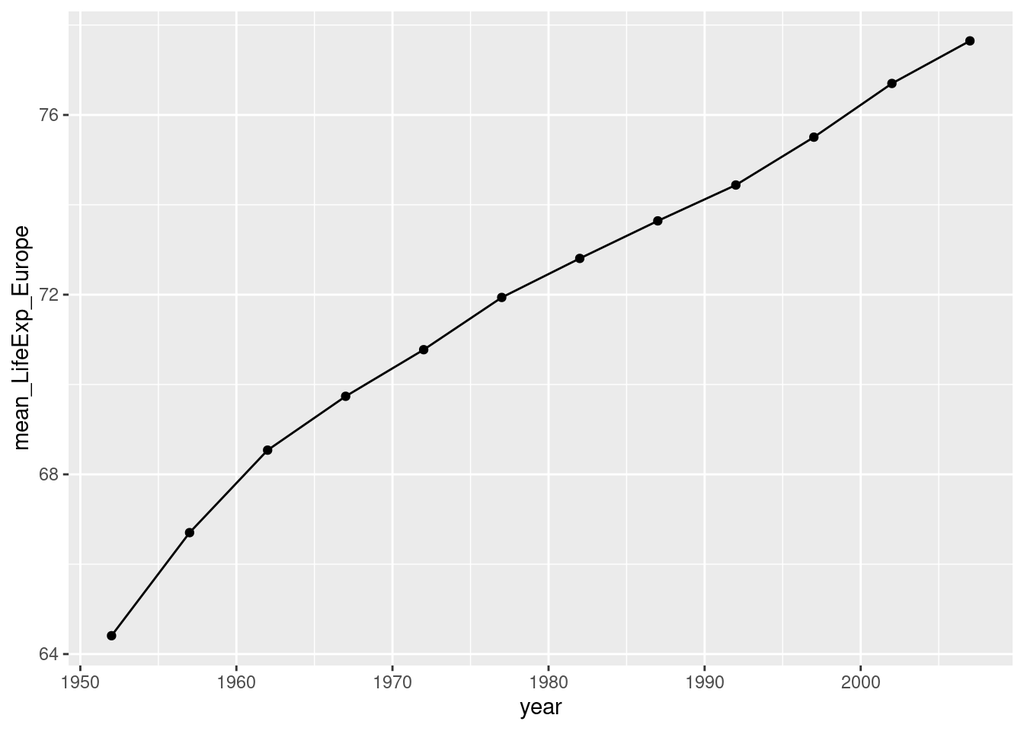

```r
ggplot(mean_res) + aes(x=year, y = mean_LifeExp_Europe) + geom_point() + geom_line()
```

22. Tracer l’évolution du PIB par habitant moyen sur chaque continent au cours du temps

```r
PIB_mean <- group_by(gapminder, year, continent) %>% summarise(MeanPIB = mean(gdpPercap))
```

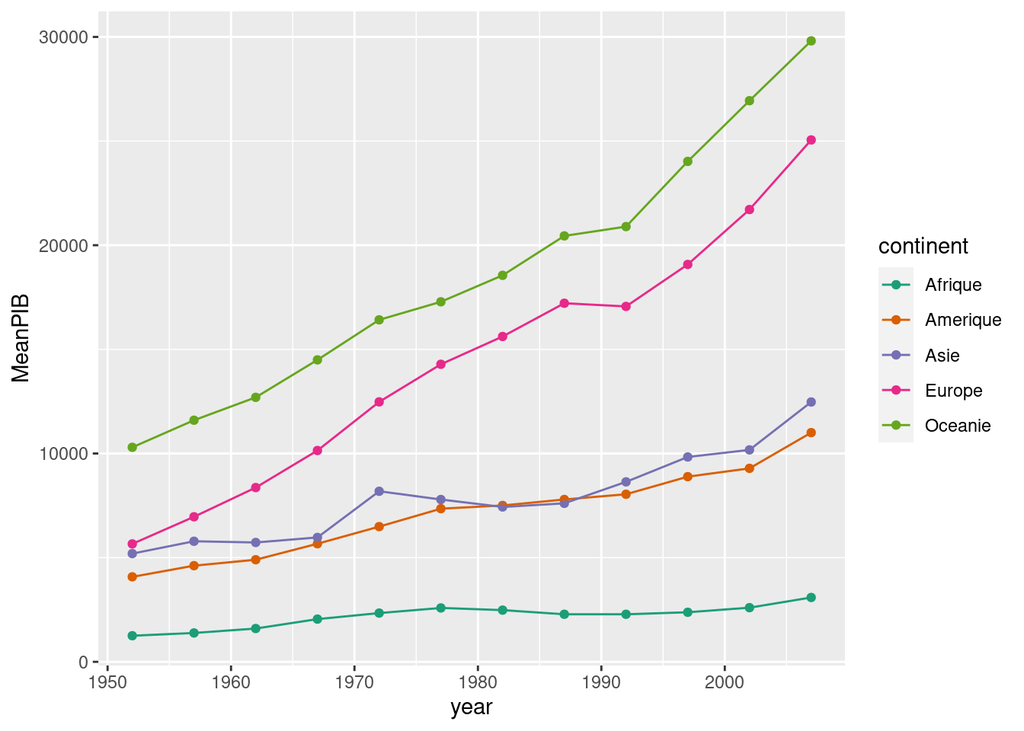

```r
PIB_mean$continent <- fct_recode(PIB_mean$continent,
                                 "Asie" = 'Asia',
                                 "Europe" = "Europe",
                                 "Afrique" = "Africa",
                                 "Oceanie" = "Oceania",
                                 "Amerique" = "Americas")
ggplot(PIB_mean) + aes(x=year, y=MeanPIB, colour = continent) +
  geom_point() +
  geom_line() +
  scale_colour_brewer(palette= 'Dark2')
```